# COD_week4_1_MGK_BTE3207

Minsik Kim

2024-09-27

# Before begin..

Let’s load the SBP dataset.

```r
dataset_sbp <- read.csv(file = "Inha/5_Lectures/2024/Advanced biostatistics/scripts/BTE3207_Advanced_Biostatistics/dataset/sbp_dataset_korea_2013-2014.csv")

head(dataset_sbp)
```

```
##   SEX BTH_G SBP DBP FBS DIS  BMI
## 1   1     1 116  78  94   4 16.6
## 2   1     1 100  60  79   4 22.3
## 3   1     1 100  60  87   4 21.9
## 4   1     1 111  70  72   4 20.2
## 5   1     1 120  80  98   4 20.0
## 6   1     1 115  79  95   4 23.1
```

# Sampling distribution and variability

Example 1

Let’s see this example. If we sample a small `subset` of data, the distribution will look different from larger set of samples.

*Original data’s histogram*

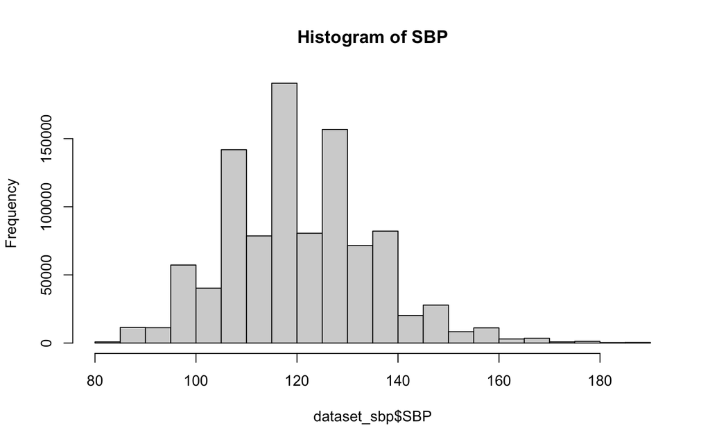

```r
hist(dataset_sbp$SBP, main = "Histogram of SBP")
```

# Sample variance

*Let’s say we sampled 2 samples from the original dataset.*

```r
set.seed(1)

print("Two randomly selecte samples")
```

```
## [1] "Two randomly selecte samples"
```

```r
dataset_sbp$SBP %>%
             sample(2)
```

```
## [1]  97 102
```

```r
print("Two randomly selecte samples -2 ")
```

```
## [1] "Two randomly selecte samples -2 "
```

```r
set.seed(2)


dataset_sbp$SBP %>%
             sample(2)
```

```
## [1] 135 110
```

Two different random samplings showed difference in mean values.

We call this sample variance.

# Sampling distribution

Let’s see how they looks like in histogram.

This time, the sample number is slightly higher.

*Histogram of 10 samples from the dataset (run 1)*

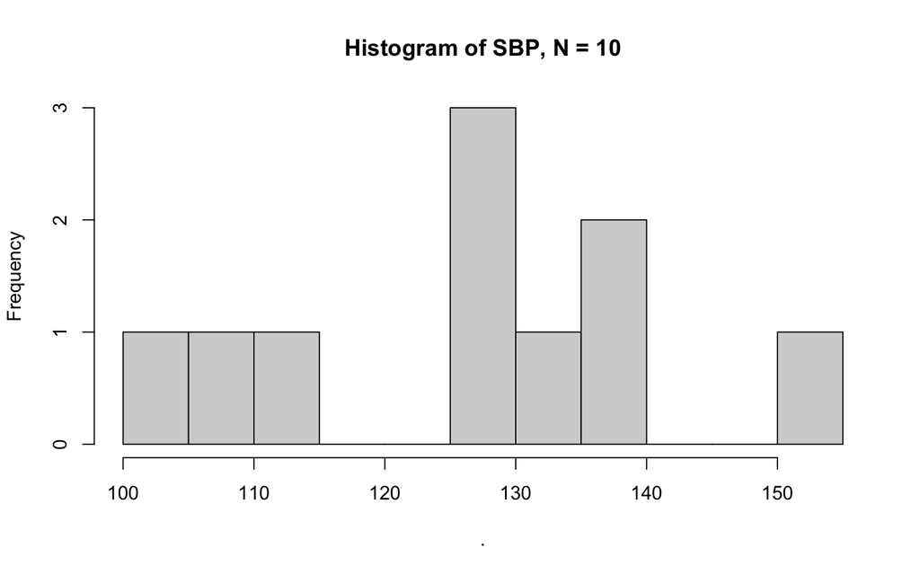

```r
dataset_sbp$SBP %>%
             sample(10) %>%
        hist(main = "Histogram of SBP, N = 10", 10)
```

*Histogram of 10 samples from the dataset (run 2)*

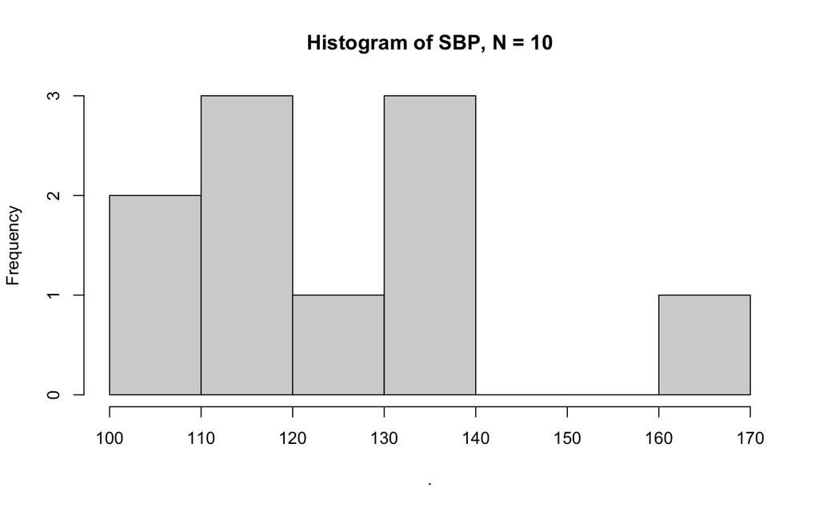

```r
dataset_sbp$SBP %>%
             sample(10) %>%
        hist(main = "Histogram of SBP, N = 10")
```

We **randomly** *sampled* 10 dataset from the `dataset_SBP` and looked at their distribution. Do you think they look the same?

No, unfortunately they are not.

Since the sampling takes samples randomly, their mean, distribution is different.

Of course, since this sampling was done by computer, we can make the sampling process *reproducible* by a `set.seed()` function in R.

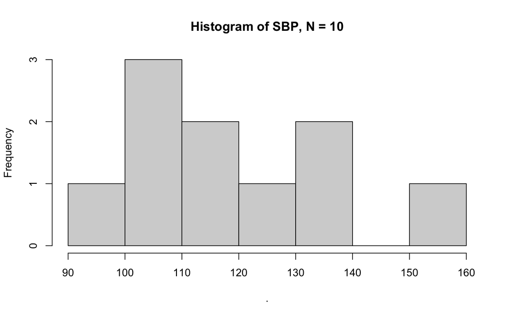

```r
set.seed(1)

dataset_sbp$SBP %>%
             sample(10) %>%
        hist(main = "Histogram of SBP, N = 10")

set.seed(1)

dataset_sbp$SBP %>%
             sample(10) %>%
        hist(main = "Histogram of SBP, N = 10")
```

If we set the seed, the sample sampling procedure will use the `seed number` (in this case it was `1`) for it’s algorithm. When the seed number is the same, the computer will generate the same data every time.

*However*, can we set seed for actual sampling processes in the real world? As it is impossible, the samples are always different from the population, and this phenomena is called `sampling variability`.

That means, in other words, the samples and their summary statistics actually cannot represent the population.

Then, how can we estimate the population?

Example data set for presentation material

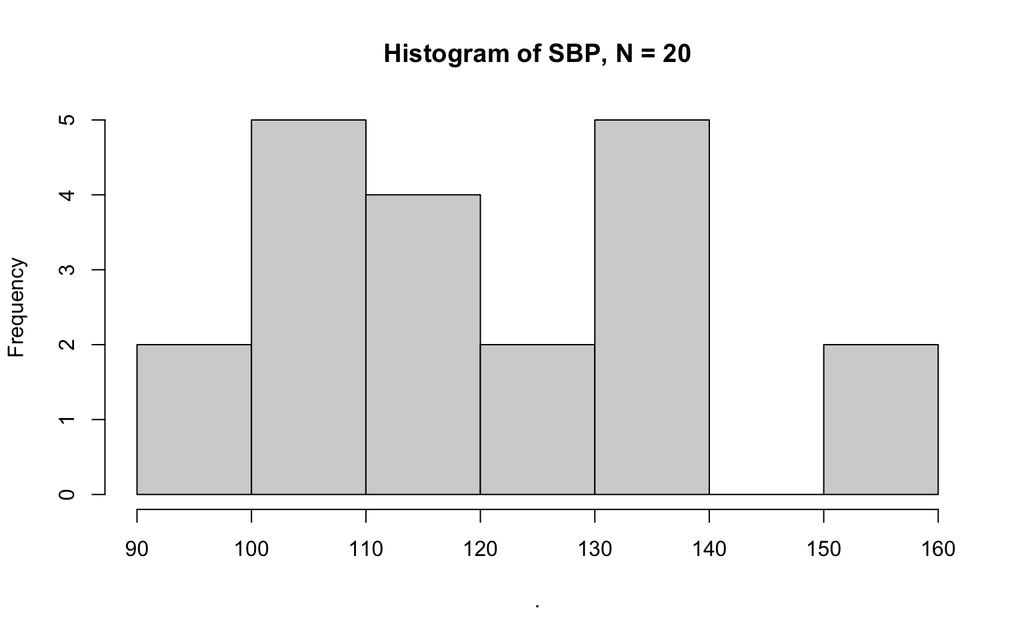

```r
set.seed(1)

dataset_sbp$SBP %>%
             sample(20) %>%
        hist(main = "Histogram of SBP, N = 20")
```

```r
dataset_sbp$SBP %>%
        sample(20) %>%
        data.frame %>%
        summarise(mean = mean(.),
                  sd = sd(.))
```

```
##     mean       sd
## 1 123.65 12.60441
```

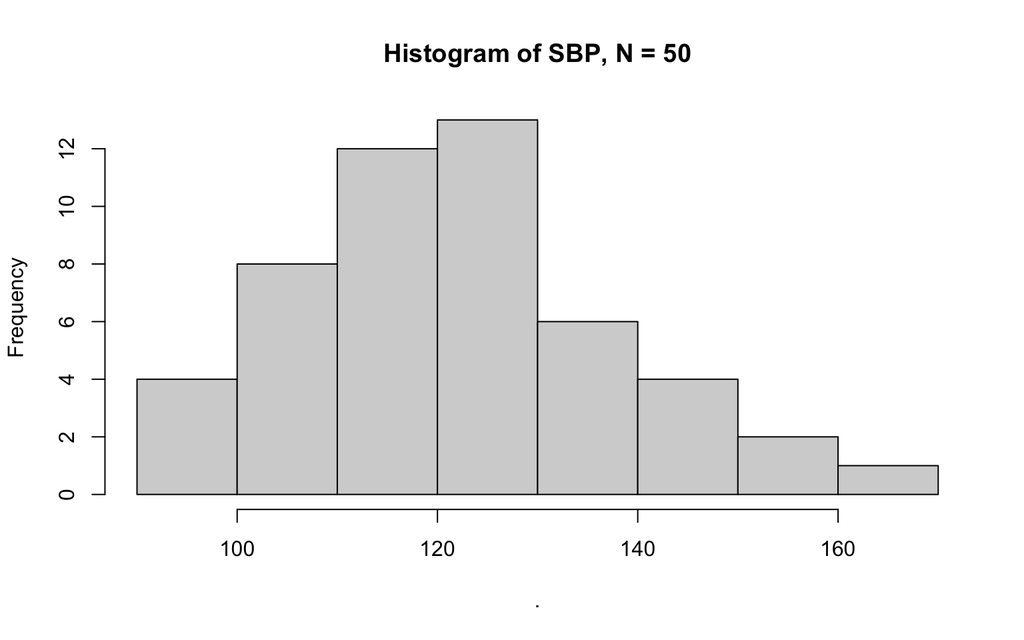

```r
set.seed(1)

dataset_sbp$SBP %>%
             sample(50) %>%
        hist(main = "Histogram of SBP, N = 50")
```

```r
dataset_sbp$SBP %>%
        sample(50) %>%
        data.frame %>%
        summarise(mean = mean(.),
                  sd = sd(.))
```

```
##     mean       sd
## 1 119.72 14.07566
```

# Sample mean

This time, let’s do some other calculations.

We are going to sample 20 samples (randomly), 5000 times. And then, let’s see its histogram

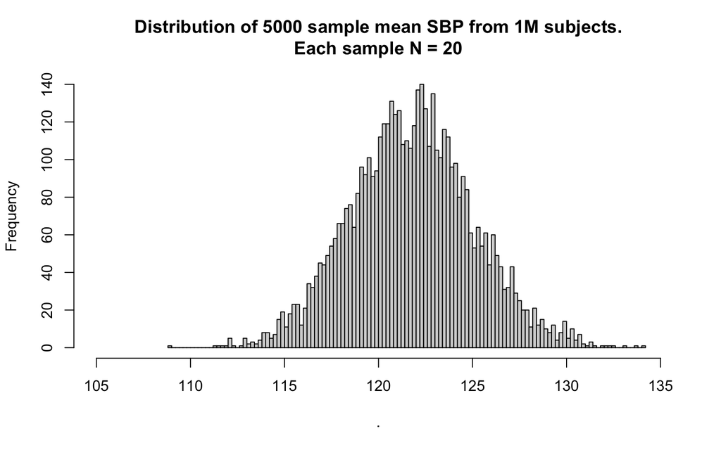

```r
set.seed(1)
replicate(5000, sample(dataset_sbp$SBP, 20)) %>%
        data.frame() %>%
        colMeans() %>%
        hist(100,
             main = "Distribution of 5000 sample mean SBP from 1M subjects.\nEach sample N = 20",
             xlim = c(105, 135))
```

What if we increase the number of random sampling?

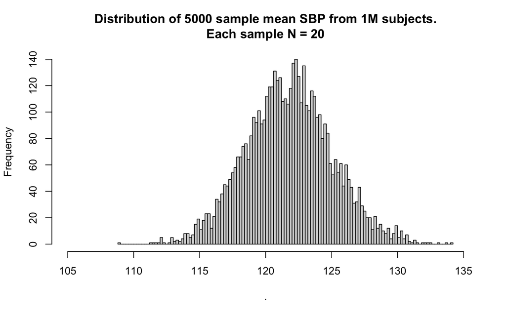

```r
set.seed(1)
replicate(5000, sample(dataset_sbp$SBP, 20)) %>%
        data.frame() %>%
        colMeans() %>%
        hist(100,
             main = "Distribution of 5000 sample mean SBP from 1M subjects.\nEach sample N = 20",
             xlim = c(105, 135))
```

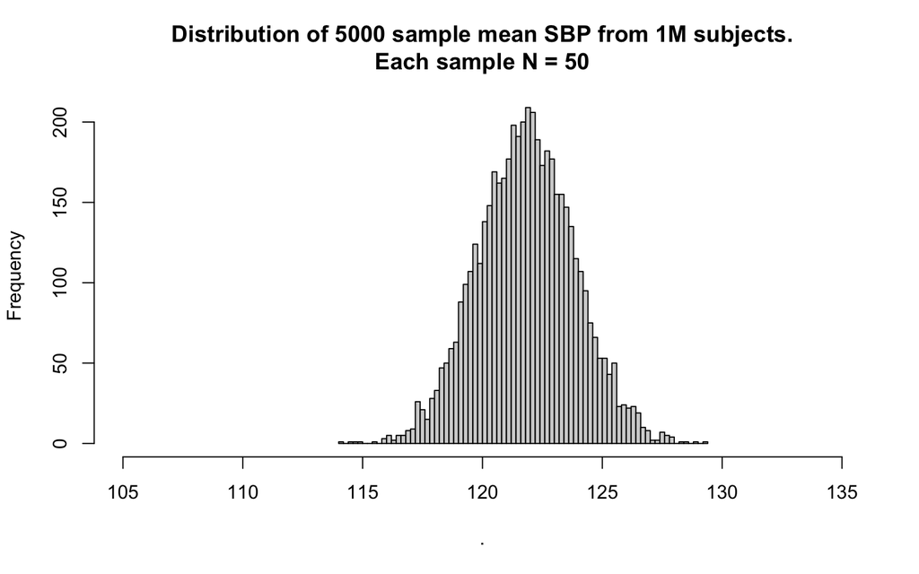

```r
set.seed(1)
replicate(5000, sample(dataset_sbp$SBP, 50)) %>%
        data.frame() %>%
        colMeans() %>%
        hist(100,
             main = "Distribution of 5000 sample mean SBP from 1M subjects.\nEach sample N = 50",
             xlim = c(105, 135))
```

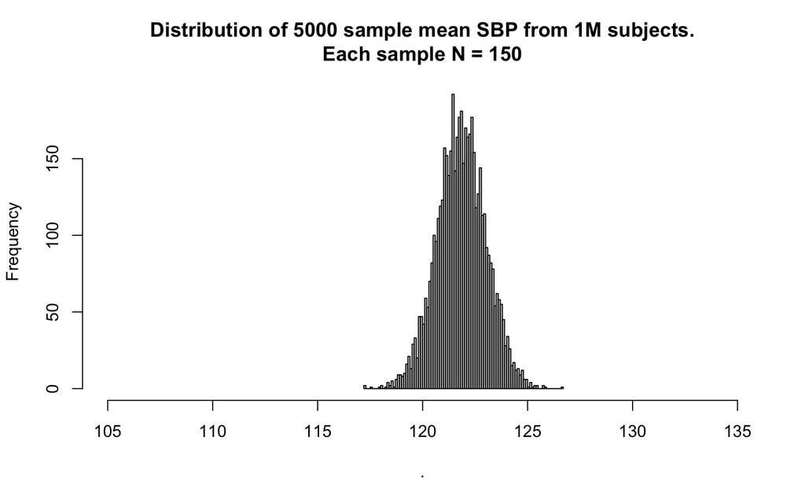

```r
set.seed(1)
replicate(5000, sample(dataset_sbp$SBP, 150)) %>%
        data.frame() %>%
        colMeans() %>%
        hist(100,
             main = "Distribution of 5000 sample mean SBP from 1M subjects.\nEach sample N = 150",
             xlim = c(105, 135))
```

How do they look?

Let’s see their variation in boxplots

[figure not shown]

```r
set.seed(1)
dataset_pbs_r5000_n50_250_400 <- data.frame(`n = 50` = (replicate(5000, sample(dataset_sbp$FBS, 50)) %>%
                               data.frame %>%
                               colMeans()),
           `n = 250` = (replicate(5000, sample(dataset_sbp$FBS, 250)) %>%
                                data.frame %>%
                                colMeans()),
           `n = 400` = (replicate(5000, sample(dataset_sbp$FBS, 400)) %>%
                                data.frame %>%
                                colMeans()),
           check.names = F
           ) %>%
        gather(condition, FBS, `n = 50`:`n = 400`, factor_key=TRUE)

dataset_pbs_r5000_n50_250_400 %>%
        boxplot(data = .,
                FBS ~ condition,
                main = "Estimated sampling distribution, \nsample mean of 5000 random samples of \nn = 50, n = 250, and n = 400",
                xlab = "Sample N of each ramdom sampling")
```

Summary table

```r
dataset_pbs_r5000_n50_250_400 %>%
        group_by(condition) %>%
        summarise(mean = mean(FBS),
                  sd = sd(FBS))
```

```
## # A tibble: 3 × 3
##   condition  mean    sd
##   <fct>     <dbl> <dbl>
## 1 n = 50     99.0  3.31
## 2 n = 250    98.9  1.44
## 3 n = 400    98.9  1.14
```

```r
dataset_sbp %>%
        summarise(mean = mean(FBS),
                  sd = sd(FBS))
```

```
##       mean      sd
## 1 98.86443 22.9813
```

Note that the change in variation is dependent on N, not the number of repeat

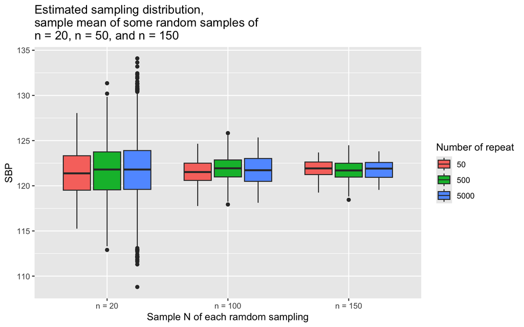

```r
set.seed(1)

dataset_sbp_r500_n20_50_150 <- data.frame(`n = 20` = (replicate(500, sample(dataset_sbp$SBP, 20)) %>%
                               data.frame %>%
                               colMeans()),
           `n = 100` = (replicate(500, sample(dataset_sbp$SBP, 100)) %>%
                                data.frame %>%
                                colMeans()),
           `n = 150` = (replicate(500, sample(dataset_sbp$SBP, 150)) %>%
                                data.frame %>%
                                colMeans()),
           check.names = F
           ) %>%
        gather(condition, SBP, `n = 20`:`n = 150`, factor_key=TRUE)

set.seed(1)

dataset_sbp_r50_n20_50_150 <- data.frame(`n = 20` = (replicate(50, sample(dataset_sbp$SBP, 20)) %>%
                               data.frame %>%
                               colMeans()),
           `n = 100` = (replicate(50, sample(dataset_sbp$SBP, 100)) %>%
                                data.frame %>%
                                colMeans()),
           `n = 150` = (replicate(50, sample(dataset_sbp$SBP, 150)) %>%
                                data.frame %>%
                                colMeans()),
           check.names = F
           ) %>%
        gather(condition, SBP, `n = 20`:`n = 150`, factor_key=TRUE)

set.seed(1)

dataset_sbp_r5000_n20_50_150 <- data.frame(`n = 20` = (replicate(5000, sample(dataset_sbp$SBP, 20)) %>%
                               data.frame %>%
                               colMeans()),
           `n = 100` = (replicate(50, sample(dataset_sbp$SBP, 100)) %>%
                                data.frame %>%
                                colMeans()),
           `n = 150` = (replicate(50, sample(dataset_sbp$SBP, 150)) %>%
                                data.frame %>%
                                colMeans()),
           check.names = F
           ) %>%
        gather(condition, SBP, `n = 20`:`n = 150`, factor_key=TRUE)

dataset_sbp_r50_n20_50_150$`Number of repeat` <- 50
dataset_sbp_r500_n20_50_150$`Number of repeat` <- 500
dataset_sbp_r5000_n20_50_150$`Number of repeat` <- 5000


rbind(dataset_sbp_r50_n20_50_150,
      dataset_sbp_r500_n20_50_150,
      dataset_sbp_r5000_n20_50_150) %>%
        mutate(`Number of repeat` = as.factor(`Number of repeat`)) %>%
        ggplot(data = ., aes(x = condition, y = SBP)) +
        geom_boxplot(aes(fill = `Number of repeat`)) +
        ggtitle("Estimated sampling distribution, \nsample mean of some random samples of \nn = 20, n = 50, and n = 150") +
        xlab("Sample N of each ramdom sampling")
```

```r
?geom_boxplot()
```

# Sample mean and sample distribution of skewed data

As same as we observed the tendency of sample means with bell-shaped dataset, we are going to investigate skewed data

*Original data’s histogram*

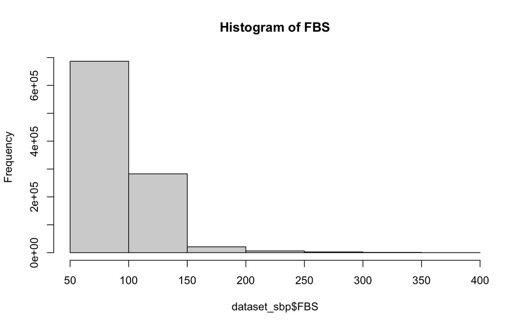

```r
hist(dataset_sbp$FBS, main = "Histogram of FBS", 10)
```

```r
dataset_sbp %>% summarise(mean = mean(FBS),
                              sd = sd(FBS))
```

```
##       mean      sd
## 1 98.86443 22.9813
```

## Sample variance

*Let’s say we sampled 2 samples from the original dataset.*

```r
set.seed(1)

print("Two randomly selected samples")
```

```
## [1] "Two randomly selected samples"
```

```r
dataset_sbp$FBS %>%
             sample(2)
```

```
## [1]  79 109
```

```r
print("Two randomly selected samples -2 ")
```

```
## [1] "Two randomly selected samples -2 "
```

```r
set.seed(2)


dataset_sbp$FBS %>%
             sample(2)
```

```
## [1] 95 91
```

Two different random samplings showed difference in mean values.

We call this sample variance.

## Sampling distribution

Let’s see how they looks like in histogram.

This time, the sample number is slightly higher.

*Histogram of 10 samples from the dataset (run 1)*

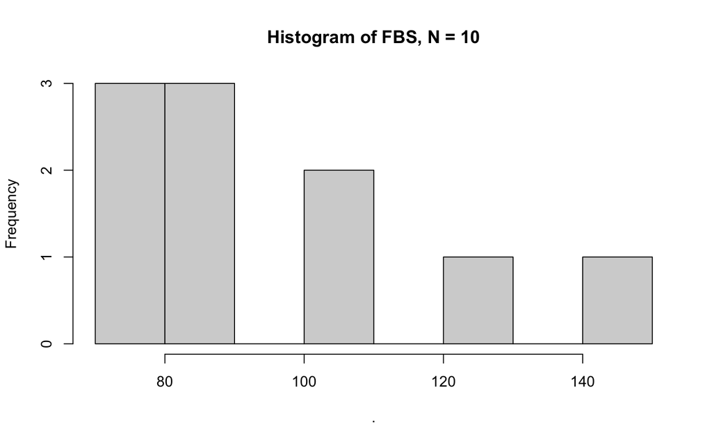

```r
set.seed(3)
dataset_sbp$FBS %>%
             sample(10) %>%
        hist(main = "Histogram of FBS, N = 10", 10)
```

```r
set.seed(3)
dataset_sbp$FBS %>%
        sample(10) %>%
        data.frame() %>%
        summarise(mean = mean(.),
                              sd = sd(.))
```

```
##   mean      sd
## 1 98.5 23.0904
```

Histograms of multiple random sampling and their sample mean

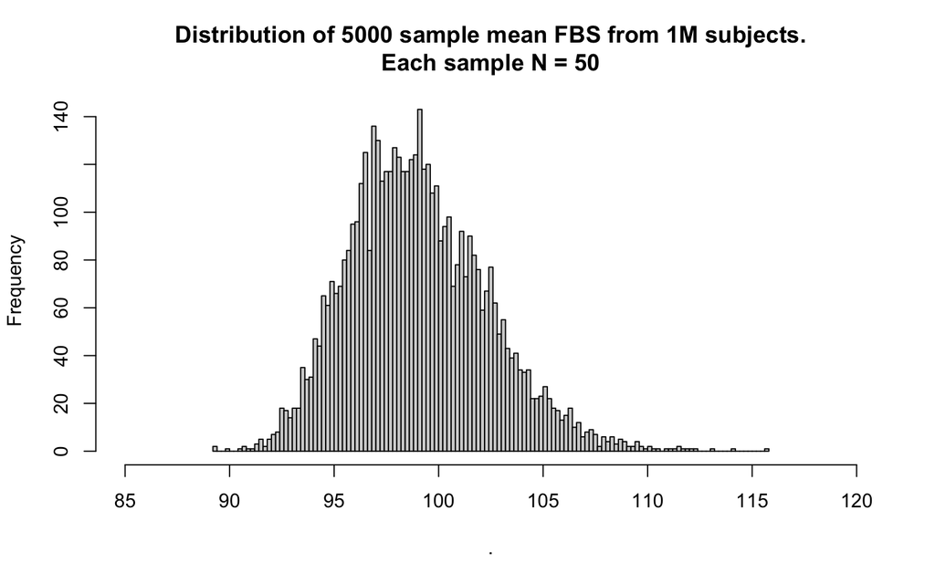

```r
set.seed(1)
replicate(5000, sample(dataset_sbp$FBS, 50)) %>%
        data.frame() %>%
        colMeans() %>%
        hist(100,
             main = "Distribution of 5000 sample mean FBS from 1M subjects.\nEach sample N = 50",
             xlim = c(85, 120))
```

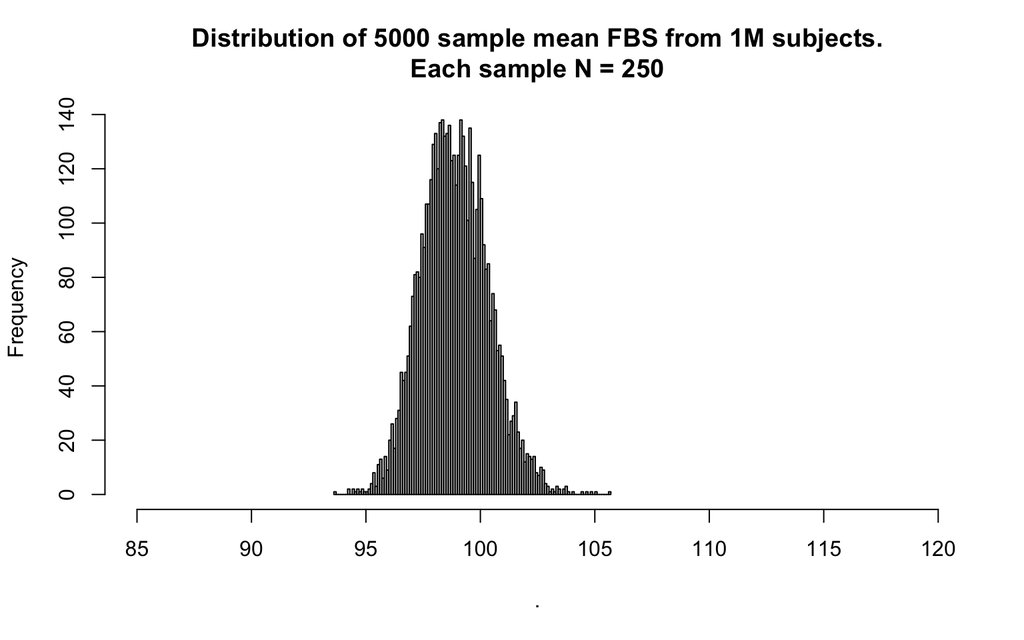

```r
set.seed(1)
replicate(5000, sample(dataset_sbp$FBS, 250)) %>%
        data.frame() %>%
        colMeans() %>%
        hist(100,
             main = "Distribution of 5000 sample mean FBS from 1M subjects.\nEach sample N = 250",
             xlim = c(85, 120))
```

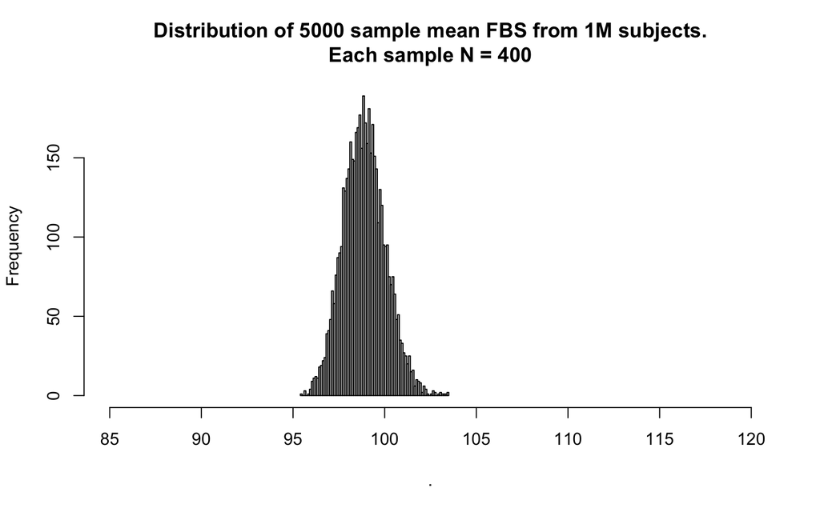

```r
set.seed(1)
replicate(5000, sample(dataset_sbp$FBS, 400)) %>%
        data.frame() %>%
        colMeans() %>%
        hist(100,
             main = "Distribution of 5000 sample mean FBS from 1M subjects.\nEach sample N = 400",
             xlim = c(85, 120))
```

How do they look?

Let’s see their variation in boxplots

[figure not shown]

```r
set.seed(1)
dataset_sbp_r5000_n20_50_150 <- data.frame(`n = 20` = (replicate(5000, sample(dataset_sbp$SBP, 20)) %>%
                               data.frame %>%
                               colMeans()),
           `n = 100` = (replicate(5000, sample(dataset_sbp$SBP, 100)) %>%
                                data.frame %>%
                                colMeans()),
           `n = 150` = (replicate(5000, sample(dataset_sbp$SBP, 150)) %>%
                                data.frame %>%
                                colMeans()),
           check.names = F
           ) %>%
        gather(condition, SBP, `n = 20`:`n = 150`, factor_key=TRUE)

dataset_sbp_r5000_n20_50_150 %>%
        boxplot(data = .,
                SBP ~ condition,
                main = "Estimated sampling distribution, \nsample mean of 5000 random samples of \nn = 20, n = 50, and n = 150",
                xlab = "Sample N of each ramdom sampling")
```

Summary table

```r
dataset_sbp_r5000_n20_50_150 %>%
        group_by(condition) %>%
        summarise(mean = mean(SBP),
                  sd = sd(SBP))
```

```
## # A tibble: 3 × 3
##   condition  mean    sd
##   <fct>     <dbl> <dbl>
## 1 n = 20     122.  3.26
## 2 n = 100    122.  1.45
## 3 n = 150    122.  1.20
```

```r
dataset_sbp %>%
        summarise(mean = mean(SBP),
                  sd = sd(SBP))
```

```
##       mean       sd
## 1 121.8718 14.56171
```

# Binary variables

Summary table

The criteria for diagnosing hyper tension (high blood pressure) is as follows.

Normal: SBP less than 120 and DBP less than 80 mm Hg; Elevated: SBP 120 to 129 and DBP less than 80 mm Hg; Stage 1 hypertension: SBP 130 to 139 or DBP 80 to 89 mm Hg; Stage 2 hypertension: SBP greater than or equal to 140 mm Hg or DBP greater than or equal to 90 mm Hg.

```r
dataset_sbp$hypertension <- ifelse(dataset_sbp$SBP > 130 | dataset_sbp$DBP > 80,
                                   1,
                                   0)
```

And the histogram of hypertension will look like this.

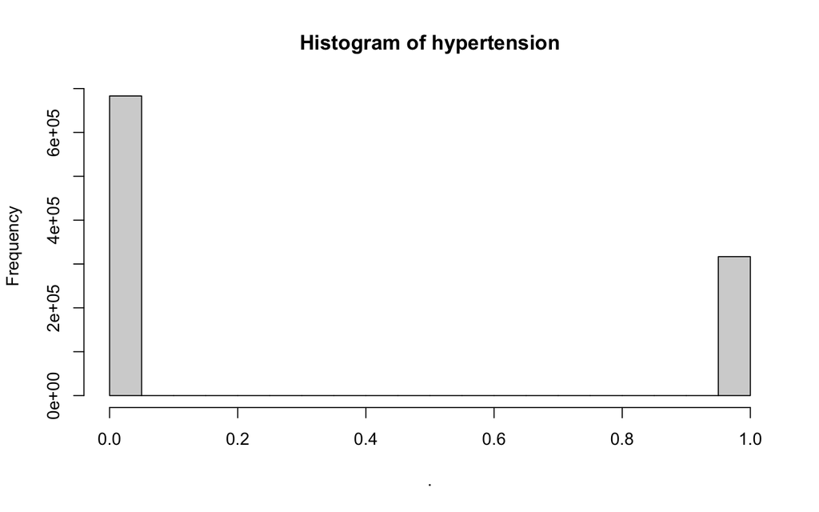

```r
dataset_sbp$hypertension %>% hist(main = "Histogram of hypertension")
```

```r
dataset_sbp$hypertension %>% mean
```

```
## [1] 0.316803
```

## Sample mean of binary variable

If we take random 50 samples, due to sampling variation, the sample mean will show different results.

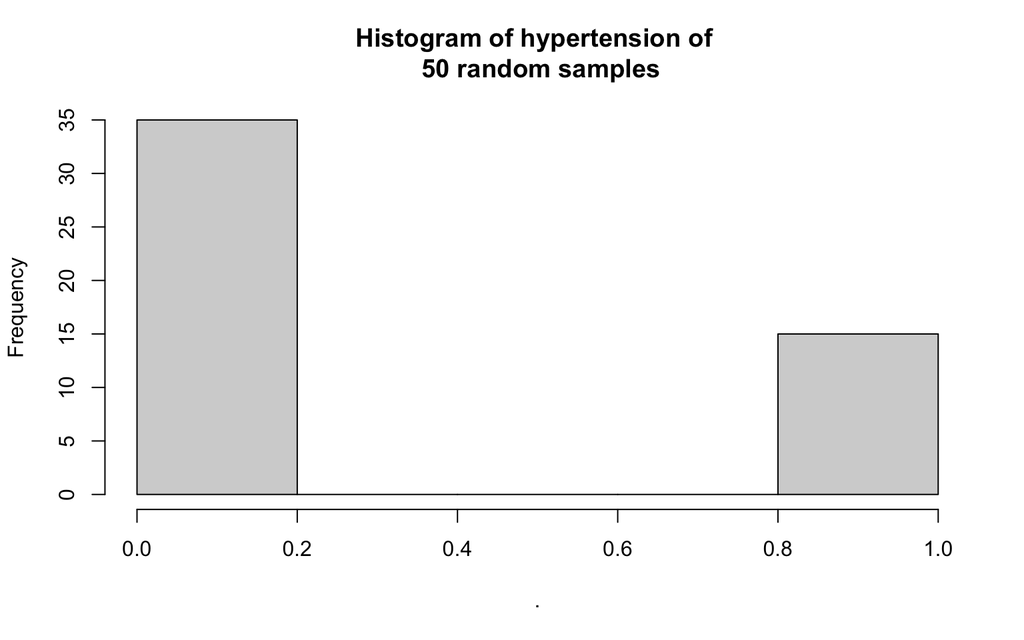

```r
set.seed(1)
dataset_sbp$hypertension %>% sample(50) %>% hist(main = "Histogram of hypertension of \n 50 random samples")
```

```r
set.seed(1)
dataset_sbp$hypertension %>% sample(50) %>% mean
```

```
## [1] 0.3
```

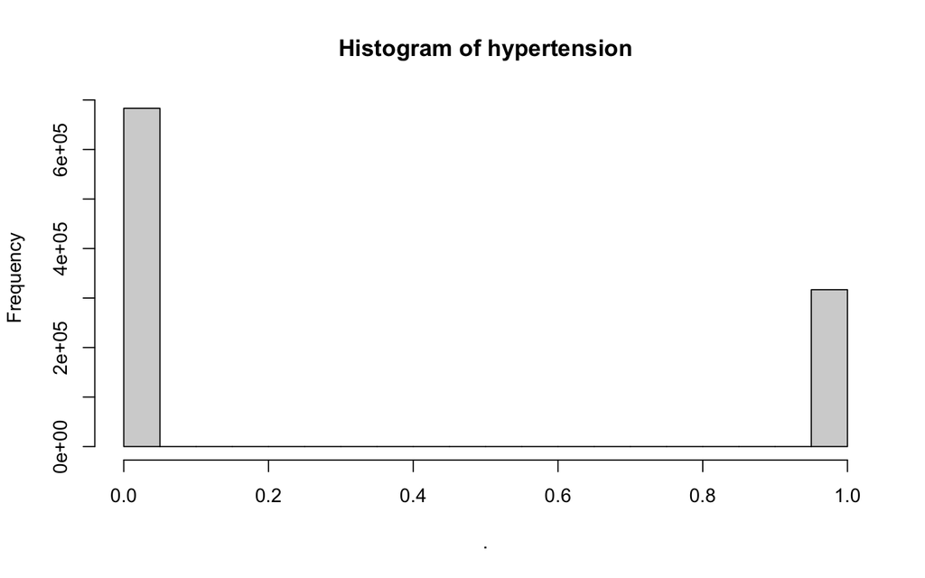

```r
dataset_sbp$hypertension %>% hist(main = "Histogram of hypertension")
```

```r
dataset_sbp$hypertension %>% mean
```

```
## [1] 0.316803
```

## Sampling distribution of binary variable

```r
set.seed(1)
h_r_5000_n50 <- replicate(5000, sample(dataset_sbp$hypertension, 50))
h_r_5000_n50 %>% data.frame() %>% colMeans()
```

[output not shown]

[output cut: 715 more lines]

[output not shown]

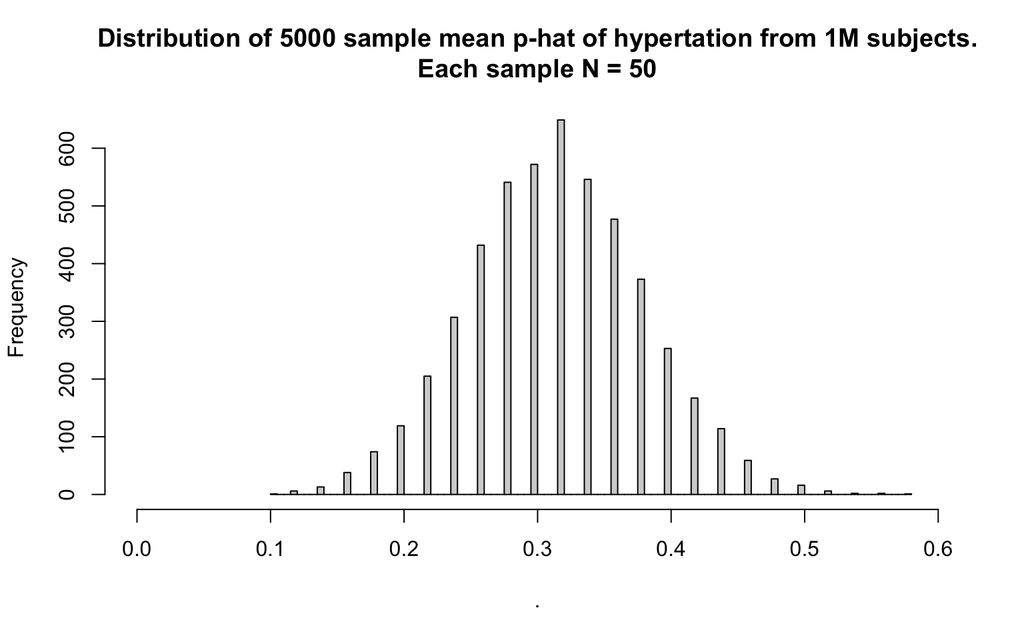

```r
replicate(5000, sample(dataset_sbp$hypertension, 50)) %>%
        data.frame() %>%
        colMeans() %>%
        hist(100,
             main = "Distribution of 5000 sample mean p-hat of hypertation from 1M subjects.\nEach sample N = 50",
             xlim = c(0, 0.6))
```

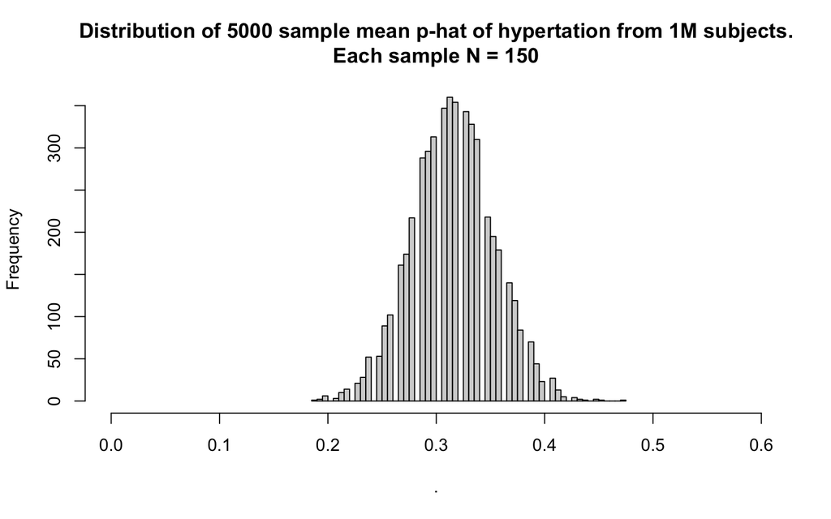

```r
set.seed(1)
replicate(5000, sample(dataset_sbp$hypertension, 150)) %>%
        data.frame() %>%
        colMeans() %>%
        hist(100,
             main = "Distribution of 5000 sample mean p-hat of hypertation from 1M subjects.\nEach sample N = 150",
             xlim = c(0, 0.6))
```

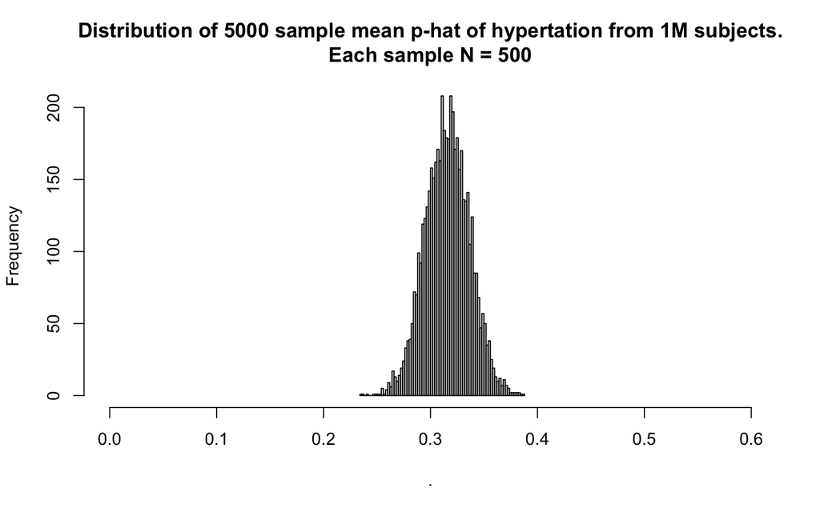

```r
set.seed(1)
replicate(5000, sample(dataset_sbp$hypertension, 500)) %>%
        data.frame() %>%
        colMeans() %>%
        hist(100,
             main = "Distribution of 5000 sample mean p-hat of hypertation from 1M subjects.\nEach sample N = 500",
xlim = c(0, 0.6))
```

## box plot

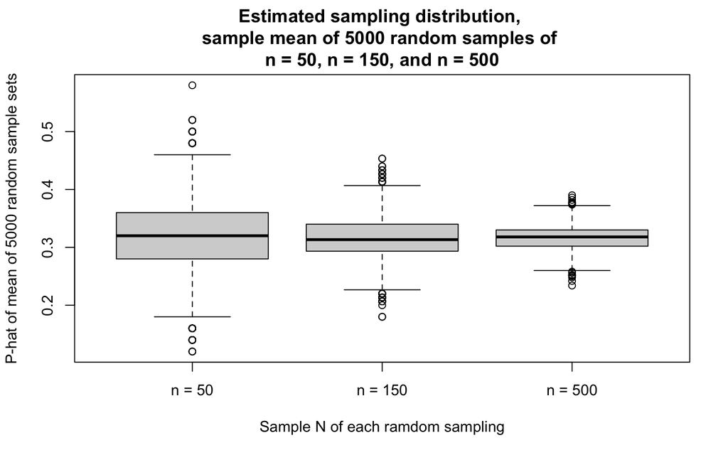

```r
set.seed(1)
dataset_hypertension_r5000_n_50_150_500 <- data.frame(`n = 50` = (replicate(5000, sample(dataset_sbp$hypertension, 50)) %>%
                               data.frame %>%
                               colMeans()),
           `n = 150` = (replicate(5000, sample(dataset_sbp$hypertension, 150)) %>%
                                data.frame %>%
                                colMeans()),
           `n = 500` = (replicate(5000, sample(dataset_sbp$hypertension, 500)) %>%
                                data.frame %>%
                                colMeans()),
           check.names = F
           ) %>%
        gather(condition, hypertension, `n = 50`:`n = 500`, factor_key=TRUE)

dataset_hypertension_r5000_n_50_150_500 %>%
        boxplot(data = .,
                hypertension ~ condition,
                main = "Estimated sampling distribution, \nsample mean of 5000 random samples of \nn = 50, n = 150, and n = 500",
                xlab = "Sample N of each ramdom sampling",
                ylab = "P-hat of mean of 5000 random sample sets")
```

## Summary table

```r
dataset_hypertension_r5000_n_50_150_500 %>%
        group_by(condition) %>%
        summarise(mean = mean(hypertension),
                  sd = sd(hypertension))
```

```
## # A tibble: 3 × 3
##   condition  mean     sd
##   <fct>     <dbl>  <dbl>
## 1 n = 50    0.316 0.0639
## 2 n = 150   0.317 0.0378
## 3 n = 500   0.317 0.0206
```

```r
dataset_sbp %>% summarise(mean = mean(hypertension),
                  sd = sd(hypertension))
```

```
##       mean        sd
## 1 0.316803 0.4652301
```

# Standard error (SE)

## Standard error of and it’s theoretical value for it’s subsets and sampling distribution

```r
dataset_sbp %>% summarise(mean = mean(SBP),
                              sd = sd(SBP))
```

```
##       mean       sd
## 1 121.8718 14.56171
```

```r
sd(dataset_sbp$SBP)/sqrt(20)
```

```
## [1] 3.256096
```

```r
sd(dataset_sbp$SBP)/sqrt(100)
```

```
## [1] 1.456171
```

```r
sd(dataset_sbp$SBP)/sqrt(150)
```

```
## [1] 1.188958
```

## Standard error of sample proportions

```r
dataset_sbp %>% summarise(mean = mean(hypertension),
                              sd = sd(hypertension))
```

```
##       mean        sd
## 1 0.316803 0.4652301
```

```r
sd(dataset_sbp$hypertension)/sqrt(50)
```

```
## [1] 0.06579348
```

```r
sd(dataset_sbp$hypertension)/sqrt(150)
```

```
## [1] 0.03798588
```

```r
sd(dataset_sbp$hypertension)/sqrt(500)
```

```
## [1] 0.02080572
```

```r
sd(dataset_sbp$hypertension)
```

```
## [1] 0.4652301
```

```r
set.seed(8)
dataset_sbp$hypertension %>% sample(100) %>% sd
```

```
## [1] 0.4943111
```

```r
set.seed(1)
dataset_sbp$hypertension %>% sample(100) %>% sd
```

```
## [1] 0.4648232
```

```r
set.seed(5)
dataset_sbp$hypertension %>% sample(100) %>% sd
```

```
## [1] 0.4512609
```

# Bibliography

[output not shown]